# Project 5

Creating data from digital sources

Stefan Walles (swal435)

2024-06-04

## Part A

The data context I selected was the differences between different types of cat breeds. I have three cats at home each with their own personalities. I was interested in finding out what effect breed had on a cat’s personality. I found a website that facilitates the adoption of cats which had information on different cat breeds and their personalities. So that is what I used for part A.

```r
library(tidyverse)
library(rvest)
library(magick)

# My data context is different cat breeds and their qualities

# I need a list of some kind with different cat breeds. I also need some information about each breed, eg. personality, colour, etc.

# Website I want to scrape: https://www.petfinder.com/cats-and-kittens/breeds/
# Terms and Conditions: https://www.petfinder.com/terms-of-service/
# Note that bots are prohibited from accessing user generated data, but not information provided by petfinder
# robots.txt: https://www.petfinder.com/robots.txt
# Only prohibits access to some pages with /user/

#=============
# Functions
#=============
# Create a vector of attribute values with the names as the attribute names
create_attr_vector <- function(list) {
  names <- character(0)
  values <- numeric(0)
  for (i in 1:length(list)) {
    names <- c(names, str_to_lower(list[[i]][1]))
    values <- c(values, as.numeric(str_remove_all(list[[i]][2], " in 5")))
  }
  names(values) <- names %>%
    str_replace_all(" ", "_")
  return(values)
}

# A function to visit each page and get a list of the urls that refers to the page that contains information on each breed
get_breed_urls <- function(urls){

  url_list <- character(0)

  for (i in 1:length(urls)) {

    Sys.sleep(2)

    breeds_page <- read_html(urls[i])

    links <- breeds_page %>%
      html_elements("#breeds-grid") %>%
      html_elements(".Card-module--articleCard--a4de8") %>%
      html_attr("href")

    url_list <- c(url_list, links)
  }
  return(url_list)
}

# Takes url to page with a breed's data and returns a dataframe
breed_data <- function(url) {
  #Delay requests
  Sys.sleep(2)
  single_page <- read_html(url)

  # Get attributes
  # Breed Name
  breed_name <- single_page %>%
    html_elements(".BreedCard-module--breedCard__title--eaa90") %>%
    html_text2() %>%
    str_remove_all(" Cats & Kittens")

  # Breed Image
  temp_img <- single_page %>%
    html_elements(".BreedCard-module--breedCard--247d8 .gatsby-image-wrapper") %>%
    html_elements("picture") %>%
    html_elements("img") %>%
    html_attr("src") %>%
    unique()

  breed_img <- paste0("https://www.petfinder.com", temp_img)

  # Description
  breed_description <- single_page %>%
    html_elements(".hasWysiwygContent") %>%
    html_text2()
  breed_description <- breed_description[1]

  # Personality attributes
  temp_attr <- single_page %>%
    html_elements(".ProgressBar-module--wrapper--c21aa") %>%
    html_text2() %>%
    unique()

  temp_attr_list <- str_split(temp_attr, "level ")
  breed_attr <- create_attr_vector(temp_attr_list)

  # Make dataframe from all gathered info 1 row
  breed_df <- tibble(breed_name, breed_img, breed_description)
  for (i in 1:length(breed_attr)) {
    breed_df <- bind_cols(breed_df, breed_attr[i])
  }
  breed_df <- breed_df %>%
    rename_with(function(t){names(breed_attr)}, .cols = paste0("...", 4:15))

  return(breed_df)
}

#======
# Work
#======
url <- "https://www.petfinder.com/cats-and-kittens/breeds/"


# Multiple pages of results: (This did not work!)
# ----------------------------------------------------------------------------
# I originally wanted to scrape all 5 pages but each page kept giving the same results

# There are 5 pages of results that I want
# urls_5_pages <- paste0(url, "?page=",1:5)

# Get a list of url extensions that point to pages with information on each breed
# breed_urls <- paste0("https://www.petfinder.com", get_breed_urls(urls_5_pages))

# Test cases with 2 different pages give same results
# test <- read_html("https://www.petfinder.com/cats-and-kittens/breeds/?page=1")
# test %>%
#   html_elements(".Card-module--articleCard--a4de8") %>%
#   html_attr("href")

# test2 <- read_html("https://www.petfinder.com/cats-and-kittens/breeds/?page=2")
# test2 %>%
#   html_elements(".Card-module--articleCard--a4de8") %>%
#   html_attr("href")
# ----------------------------------------------------------------------------

# Get URLs to breed pages
breed_urls <- paste0("https://www.petfinder.com", get_breed_urls(url))

# Make dataframe with all data
cat_breed_data <- map_df(breed_urls, breed_data)

# Name and output named vectors
name <- cat_breed_data$breed_name
images <- cat_breed_data$breed_img
description <- cat_breed_data$breed_description
playfulness <- cat_breed_data$playfulness

name
```

```
##  [1] "Abyssinian"         "American Bobtail"   "American Curl"
##  [4] "American Shorthair" "American Wirehair"  "Balinese"
##  [7] "Bengal"             "Birman"             "Bombay"
## [10] "British Shorthair"  "Burmese"            "Burmilla"
## [13] "Calico"             "Chartreux"
```

```r
images
```

```
##  [1] "https://www.petfinder.com/static/2ce6dadf779b6e9dab56f15057ae5246/7209f/abyssinian-detail.jpg"
##  [2] "https://www.petfinder.com/static/8ddcb795ea3d49baa5b301f569bda9ee/34122/American-Bobtail-01.jpg"
##  [3] "https://www.petfinder.com/static/ba9e5f91f187eab2197c1049591fb892/49337/american-curl-detail-scaled.jpg"
##  [4] "https://www.petfinder.com/static/9d629f7236ebd162751ab91e4b9bc5ae/1734b/american-shorthair-detail-scaled.jpg"
##  [5] "https://www.petfinder.com/static/b5c4bbe3ed8c3ebc5049871f37c77aee/49337/american-wirehair-detail.jpg"
##  [6] "https://www.petfinder.com/static/9dfcf4c144182b8ab20f3d8ada459f7d/c32e2/balinese-card-large.jpg"
##  [7] "https://www.petfinder.com/static/aee20af74e36c51e539d1600660b5f4f/c32e2/bengal-card-large.jpg"
##  [8] "https://www.petfinder.com/static/66513b2643c2df2117b235d12f059e72/c32e2/birman-card-large.jpg"
##  [9] "https://www.petfinder.com/static/688cf17eb9072ca995a6585f45404a5b/c32e2/bombay-card-large.jpg"
## [10] "https://www.petfinder.com/static/14d637ed767af6cba943a19d0a668923/c32e2/british-shorthair-card-large.jpg"
## [11] "https://www.petfinder.com/static/0afb7a860ffbdfb343f09ba631dd68d0/c32e2/burmese-card-large.jpg"
## [12] "https://www.petfinder.com/static/283df2f293c6aaba249651a3fc9896f9/c32e2/burmilla-card-large.jpg"
## [13] "https://www.petfinder.com/static/7b4830ae9dbfd239ac8a8aef9f9a26a6/afe44/PF_Calico_600x260.jpg"
## [14] "https://www.petfinder.com/static/e1c3494d3107b7f6ed4312c8d77cd8e2/c32e2/chartreux-card-large.jpg"
```

```r
description
```

```
##  [1] "The Abyssinian is often a colorful cat with a distinctly ticked coat, medium in size and regal in appearance; lithe, hard and muscular, showing eager activity and lively interest in their surroundings. They are often well balanced temperamentally and physically.\n\n\r"
##  [2] "The American Bobtail is generally medium to large cat, with a naturally occurring bobbed tail. The American Bobtail is athletic and usually well-muscled with a sometimes powerful look. They possess a natural hunting gaze that combined with their body type, give American Bobtail a distinctiv…
##  [3] "The distinctive feature of the American Curl is their attractive, uniquely curled-back ears. Elegant, well balanced, moderately muscled, slender rather than massive in build. They often appear well proportioned and balanced and can vary in size.\n\n\r"
##  [4] "The American Shorthair is a true breed of working cat. The general effect is that of a strongly built, well balanced, symmetrical cat with conformation indicating power, endurance, and agility. \n\n\r"
##  [5] "The American Wirehair cat resulted as a spontaneous mutation. Their coat, which is not only springy, dense, and resilient, but also coarse and hard to the touch, distinguishes the American Wirehair from all other breeds.\n\n\r"
##  [6] "The Balinese is often a svelte cat with long tapering lines, very lithe but strong and muscular. The Balinese is unique with their distinct range of colors and silky coat that hides a supple and athletic body. \n\n\r"
##  [7] "The Bengal is a domestic cat that has physical features distinctive to the small forest-dwelling wildcats, and with the loving, dependable temperament of a family pet. As such, some characteristics in the appearance of the Bengal are distinct from those found in other domestic cat breeds.\n…
##  [8] "A cat of mystery and legend, the Birman is a colorpointed cat with long silky hair and four pure white feet. They are often strongly built, elongated and stocky, neither svelte nor stocky. Their distinctive head has strong jaws, firm chin, and medium length nose.\n\n\r"
##  [9] "The Bombay is a medium-size cat, well-balanced, friendly, alert, and outgoing; muscular and having a surprising weight for their size. Their body and tail is usually of medium length, their head rounded with medium-sized, wide-set ears, a moderate nose stop, which is visible, large rounded …
## [10] "The British Shorthair is a compact, well-balanced, and powerful cat, with a short, very dense coat. They often convey an overall impression of balance and proportion in which no feature is exaggerated.\n\n\r"
## [11] "The Burmese is a cat of medium size with substantial bone structure, good muscular development, and a surprising weight for their size. This together with a rounded head, expressive eyes, and a sweet expression presents a totally distinctive cat who is comparable to no other breed.\n\n\r"
## [12] "The Burmilla’s appearance is that of an elegant cat of foreign type and medium size.\n\n\r"
## [13] "Calico cats are wonderful! Keep in mind, calico cats are not a breed. Instead, calico refers to their tri-color coats which include black, orange and white. \"Dilute\" calicos may have gray, beige and white instead. Despite rumors to the contrary, calico cats are not all female, either—out …
## [14] "General\n\r \r\n\nThe Chartreux is a sturdy, shorthaired French breed coveted in antiquity for its hunting prowess and its dense, water repellent fur. This breed’s husky, robust type is sometimes termed primitive, neither cobby nor classic. Though amply built, Chartreux are extremely supple…
```

```r
playfulness
```

```
## playfulness playfulness playfulness playfulness playfulness playfulness
##           5           4           4           4           4           5
## playfulness playfulness playfulness playfulness playfulness playfulness
##           5           4           4           3           5           4
## playfulness playfulness
##           3           3
```

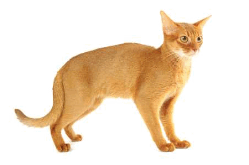

```r
# Cat Bribe
cat_breed_data$breed_img %>%
  image_read() %>%
  image_scale(geometry = "500x500") %>%
  image_animate(fps = 1)
```

## Part B

```r
library(tidyverse)
library(rvest)

# I have selected Minister Hon Erica Stanford
# Features I have noticed:
# My first and second article has vastly different *numbers of words*
# Paragraphs seem quite short only one or two sentences per paragraph
# Number of words and *number of paragraphs* are probably correlated.
# These releases also seem quote heavy, we could count the number of quotes
# Releases also all come with a date


# Get release URLs with given code
url <- "https://www.beehive.govt.nz/minister/hon-erica-stanford"

pages <- read_html(url) %>%
  html_elements(".release__wrapper") %>%
  html_elements("h2") %>%
  html_elements("a") %>%
  html_attr("href") %>%
  paste0("https://www.beehive.govt.nz", .)

# Get Title and content for one page
page_url <- pages[1]

page <- read_html(page_url)

release_title <- page %>%
  html_elements(".article__title") %>%
  html_text2()

release_content <- page %>%
  html_elements(".prose") %>%
  html_text2()

# Function to get info from page (with given code)
get_release <- function(page_url){
  Sys.sleep(2)
  # print the page_url so if things go wrong
  # we can see which page caused issues
  print(page_url)
  page <- read_html(page_url)

  # add code to scrape the release title and release content
  release_title <- page %>%
    html_elements(".article__title") %>%
    html_text2()

  release_content <- page %>%
    html_elements(".prose") %>%
    html_text2()
  # add code to return a tibble created using these data objects
  return(tibble(release_title, release_content))
}

# Make Data Frame
release_data <- map_df(pages, get_release)

# Analysis
# Number of words in each release content
release_data <- release_data %>%
  separate_rows(release_content) %>%
  count(release_title) %>%
  rename(num_words = n) %>%
  inner_join(release_data)

# Number of paragraphs per release content
release_data <- release_data %>%
  separate_rows(release_content, sep = "\n\n") %>%
  count(release_title) %>%
  rename(num_paragraphs = n) %>%
  inner_join(release_data)

# Number of quotes
# Assuming only one quote per paragraph
release_data  <- release_data %>%
  separate_rows(release_content, sep = "\n\n") %>%
  mutate(has_quote = str_detect(release_content, '“')) %>%
  group_by(release_title) %>%
  summarise(num_quotes = sum(has_quote)) %>%
  select(release_title, num_quotes) %>%
  inner_join(release_data)

# Hon Erica Stanford is the Minister for Education and Immigration
# We want to classify each release to one of the two departments
# We will count the number of times "education" or "immigration" appears and classify accordingly

release_data <- release_data %>%
  mutate(release_content = str_to_lower(release_content),
         release_content = str_remove_all(release_content, "[[:punct:]]")) %>%
  separate_rows(release_content) %>%
  mutate(is_education = str_detect(release_content, "education"),
         is_immigration = str_detect(release_content, "immigration")) %>%
  group_by(release_title) %>%
  summarise(total_education = sum(is_education),
            total_immigration = sum(is_immigration)) %>%
  mutate(department = ifelse(total_education > total_immigration,
                            "Education", "Immigration")) %>%
  select(release_title, department) %>%
  inner_join(release_data)

# Named summary values
mean_number_of_words <- round(mean(release_data$num_words), 2)

mean_number_of_words_per_paragraph <- round(
  sum(release_data$num_words) / sum(release_data$num_paragraphs), 2)

mean_number_of_quotes <- round(mean(release_data$num_quotes), 2)

percentage_of_education_releases <- round(
  sum(release_data$department == "Education") / length(release_data$department) * 100, 2)
```

I investigated four aspects with regards to Minister Hon Erica Stanford’s releases:

- On average her releases have 403.88 words.
- On average each paragraph in the releases contained 33.31 words.
- I noticed that her releases were quite quote heavy. On average each release contained 6.88 quotes.
- Minister Hon Erica Stanford is the minister for education and immigration.However, 87.5% of her releases are about education.

## Part C

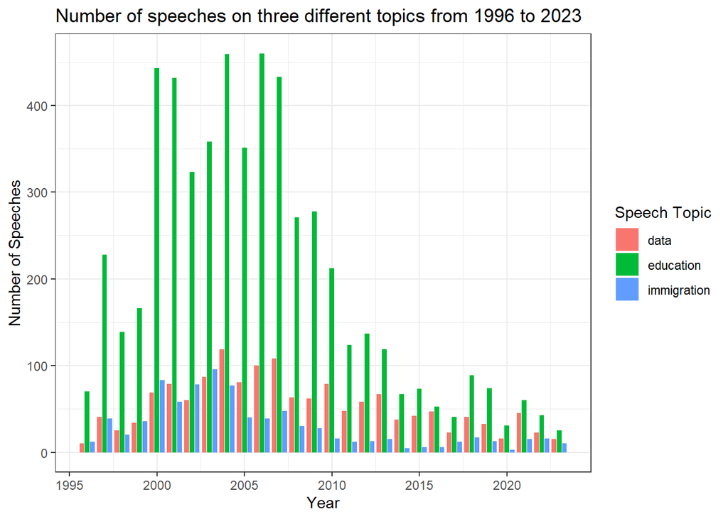

```r
library(tidyverse)
library(rvest)

# Given code, slightly modified
keywords <- c("education", "immigration", "data")

make_df <- function(i) {
search1 <- read_html(paste0("https://datalandscapes.online/scrapeable/speeches.php?search=", keywords[i])) %>%
  html_elements(".speech_summary") %>%
  html_text2() %>%
  tibble(keyword = keywords[i],
         results = .) %>%
  separate(results, into = c("year", "num_speeches"), sep = "--") %>%
  mutate(num_speeches = parse_number(num_speeches),
         year = parse_number(year))
return(search1)
}

# "When you are copy and pasting three time do something better."
# Create data frame
search1 <- make_df(1)
search2 <- make_df(2)
search3 <- make_df(3)

combined_search <- bind_rows(search1, search2, search3)

# Speeches Governments data
speeches_governments <- read_csv("https://docs.google.com/spreadsheets/d/e/2PACX-1vRHTFJcFmsIkjaFUCEwFWASaBOAR4X2Upx66C5Bhgc_WNc2JxxdRbbvyoewmvt_EjNdCNZZzzkENwLg/pub?gid=0&single=true&output=csv")

speech_data <- inner_join(combined_search, speeches_governments, by = "year")

# Visualisation
speech_data %>%
  ggplot(aes(x = year, y = num_speeches, fill = keyword)) +
  geom_col(position = "dodge2") +
  labs(title = "Number of speeches on three different topics from 1996 to 2023",
       x = "Year",
       y = "Number of Speeches",
       fill = "Speech Topic") +
  theme_bw()
```

From the visualisation we can clearly see that Education was a very popular topic, in the past, compared to data and immigration, but that it has become less popular in more recent years.

## Learning Reflextion

The thing I most enjoyed learning about in this module was web scraping. I think it is really important as it allows you access to stores of information that otherwise would be very cumbersome to collect or get access to. I do however recognise my responsibility to make sure that I am allowed to scrape data before I do so.

During Task A I ran into a problem where search results were distributed over several pages, but the URLs for each of these pages would return the same results. In the end I only used results from the first page. I would like to expand my knowledge about web scraping and websites in general to be able to fix similar issues in the future.

## Self Review

Thinking back I learned a lot while working on the 5 projects for this course.

One thing that I really enjoyed learning about was creating plots using ggplots2. I have learned how to create many different kinds of plots and how to customise them to fit my needs.

Another important thing I learned was about collecting and using data from digital sources. In project 1 we used a Google form together with a published Google document to collect data and report on it in a dynamic way. For project 4 we used an API and for project 5 we used web scraping. These concepts allows me to easily access data that otherwise could have been difficult to obtain.

Learning outcome 5: “Select and combine a range of data technologies, including HTML and CSS for reporting and web scraping” describes what I believe is the most important thing that I have learned. Using and taking advantage of these technologies not only makes things easier, but also allows for more effective reporting and communication.